**Boston scaled summary table**

```r
Boston_summary_scaled= do.call(cbind, lapply(boston_scaled, summary))

kable(Boston_summary_scaled,"html") %>%   kable_styling(bootstrap_options ="condensed",  font_size = 13, full_width = F, position = "left") %>% column_spec(1:1, bold = T,color = "white", background = "green") %>% row_spec(0, bold = T,  color = "white", background = "green")
```

|  | crim | zn | indus | chas | nox | rm | age | dis | rad | tax | ptratio | black | lstat | medv |
| --- | --- | --- | --- | --- | --- | --- | --- | --- | --- | --- | --- | --- | --- | --- |
| Min. | -0.4193669 | -0.4872402 | -1.5563017 | -0.2723291 | -1.4644327 | -3.8764132 | -2.3331282 | -1.2658165 | -0.9818712 | -1.3126910 | -2.7047025 | -3.9033305 | -1.5296134 | -1.9063399 |
| 1st Qu. | -0.4105633 | -0.4872402 | -0.8668328 | -0.2723291 | -0.9121262 | -0.5680681 | -0.8366200 | -0.8048913 | -0.6373311 | -0.7668172 | -0.4875567 | 0.2048688 | -0.7986296 | -0.5988631 |
| Median | -0.3902803 | -0.4872402 | -0.2108898 | -0.2723291 | -0.1440749 | -0.1083583 | 0.3170678 | -0.2790473 | -0.5224844 | -0.4642132 | 0.2745872 | 0.3808097 | -0.1810744 | -0.1449159 |
| Mean | 0.0000000 | 0.0000000 | 0.0000000 | 0.0000000 | 0.0000000 | 0.0000000 | 0.0000000 | 0.0000000 | 0.0000000 | 0.0000000 | 0.0000000 | 0.0000000 | 0.0000000 | 0.0000000 |
| 3rd Qu. | 0.0073892 | 0.0487240 | 1.0149946 | -0.2723291 | 0.5980871 | 0.4822906 | 0.9059016 | 0.6617161 | 1.6596029 | 1.5294129 | 0.8057784 | 0.4332223 | 0.6024226 | 0.2682577 |
| Max. | 9.9241096 | 3.8004735 | 2.4201701 | 3.6647712 | 2.7296452 | 3.5515296 | 1.1163897 | 3.9566022 | 1.6596029 | 1.7964164 | 1.6372081 | 0.4406159 | 3.5452624 | 2.9865046 |

One of the main goal of standardizeing the data is to able compare different data setes. The Boston data setes is scaled using the R funciton **`scale()`**. From the above summary table of the scaled data set, we can clearly see that each variable has a mean 0.

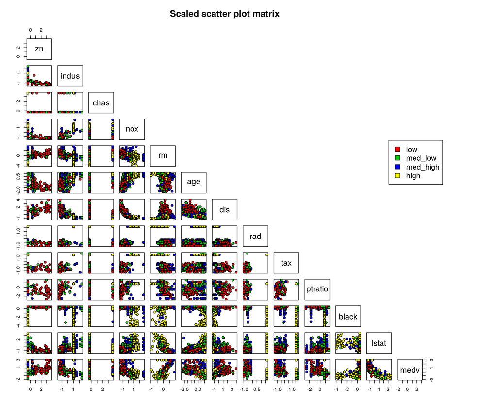

```r
bins <- quantile(boston_scaled$crim)
crime <- cut(boston_scaled$crim, breaks = bins, include.lowest = TRUE, label=c("low", "med_low", "med_high", "high"))
boston_scaled <- dplyr::select(boston_scaled, -crim)
boston_scaled <- data.frame(boston_scaled, crime)
pairs(boston_scaled[1:13], main = "Scaled scatter plot matrix",
      pch = 21, bg = c("red", "green3", "blue","yellow")[boston_scaled$crime],
      oma=c(4,4,6,12),upper.panel = NULL)
par(xpd=TRUE)
legend(0.85, 0.7, as.vector(unique(boston_scaled$crime)),
       fill=c("red", "green3", "blue","yellow"))
```

In scaling the Boston variable, subtract its mean from the variable and divided by its standard devaiation and all the mean became 0 and standard deviation 1. Moreover all the Boston varabiable is standardized using the formula $\frac{X-\mu}{\sigma}$, there is a change in each of the varible values and we can clearly see big differnce in scaled Boston and orginal Boston data set. For example, if we compare the summary table of the scaled and orginal Boston data set the maximum and minum values are not the same and also the Quantile values. However the corrlation values has not changed in both datasets.

```r
n <- nrow(boston_scaled)

# choose randomly 80% of the rows
ind <- sample(n,  size = n * 0.8)

train <- boston_scaled[ind,]

test <- boston_scaled[-ind,]

# save the correct classes from test data
correct_classes <- test$crime

# remove the crime variable from test data
test <- dplyr::select(test, -crime)
```

[output not shown]

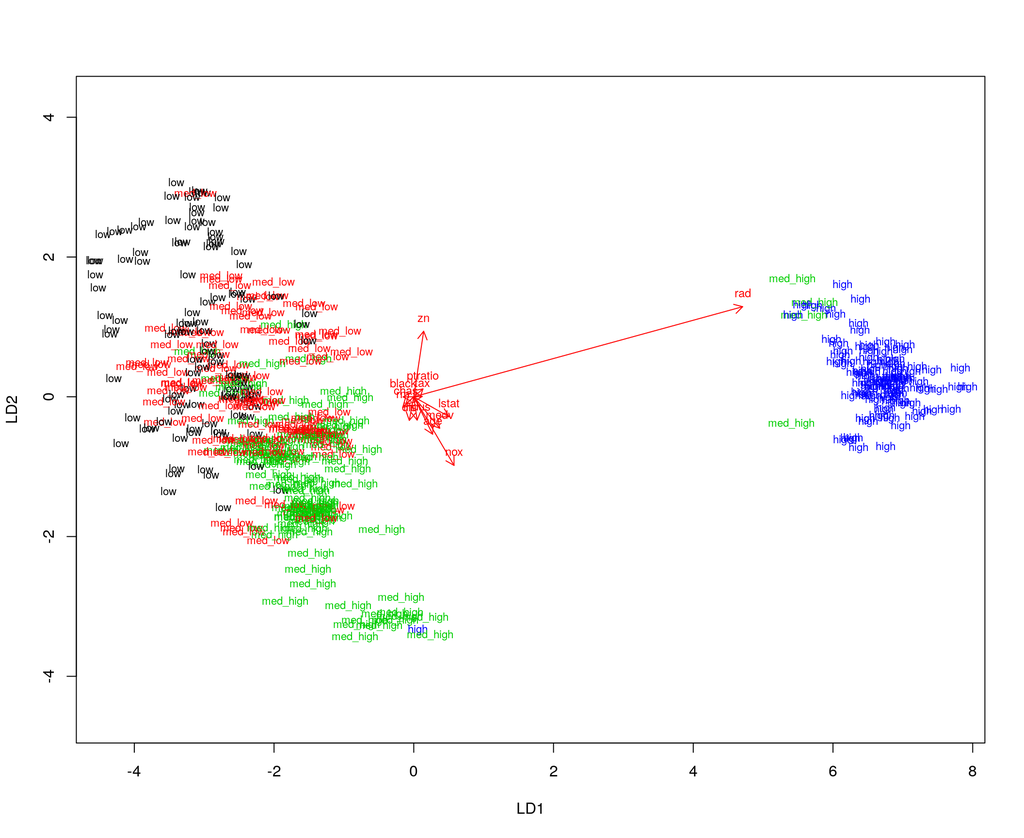

```r
lda.arrows <- function(x, myscale = 1, arrow_heads = 0.1, color = "red", tex = 0.75, choices = c(1,2)){
  heads <- coef(x)
  arrows(x0 = 0, y0 = 0,
         x1 = myscale * heads[,choices[1]],
         y1 = myscale * heads[,choices[2]], col=color, length = arrow_heads)
  text(myscale * heads[,choices], labels = row.names(heads),
       cex = tex, col=color, pos=3)
}

classes <- as.numeric(train$crime)

# plot the lda results
plot(lda.fit, dimen = 2, col=classes)
lda.arrows(lda.fit, myscale = 1.4)
```

In the above biplot, **the index of accessibility to radial highways (rad)** has the largest possible variance (that is, accounts for as much of the variability in the Boston data as possible).

```r
lda.pred <- predict(lda.fit, newdata = test)

table(correct = correct_classes, predicted = lda.pred$class)
```

```
##           predicted
## correct    low med_low med_high high
##   low       12       9        1    0
##   med_low    8      15        8    0
##   med_high   0      10       14    2
##   high       0       0        0   23
```

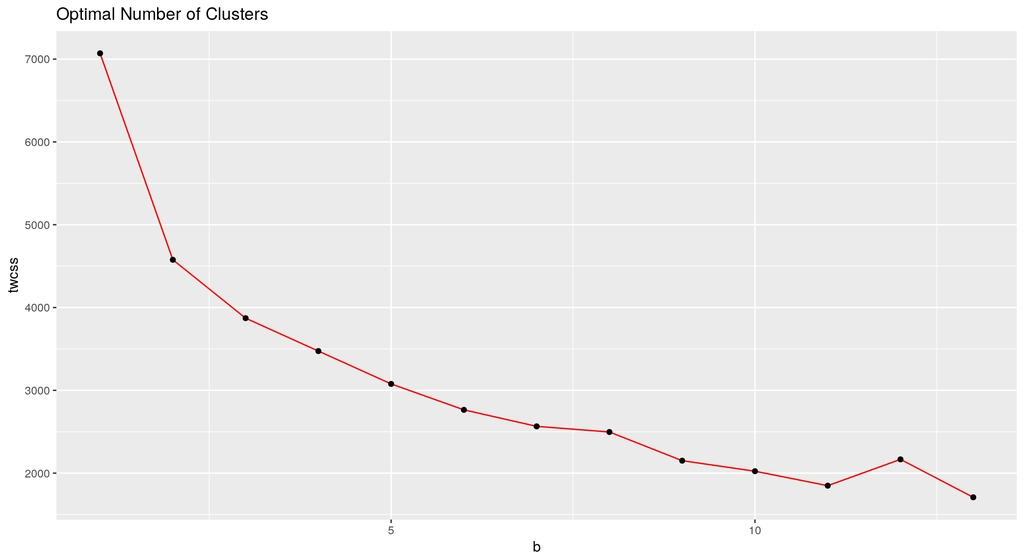

```r
data('Boston')

boston_scaled2 <- scale(Boston)

dist_eu <- dist(boston_scaled2)

set.seed(12345)

k_max <- 13

twcss <- sapply(1:k_max, function(k){kmeans(boston_scaled2, k)$tot.withinss})

#qplot(x = 1:k_max, y = twcss, geom =c("point", "line"),span = 0.2)

# k-means clustering
b=x = 1:k_max
aa=data.frame(cbind(b,twcss))

ggplot(data=aa, aes(x=b, y=twcss, group=1)) +
  geom_line(color="red")+
  geom_point() + ggtitle("Optimal Number of Clusters")
```

Assuming the above optimal number cluster is valid and the K-Means algorithm run again and the plot results are displayed below:

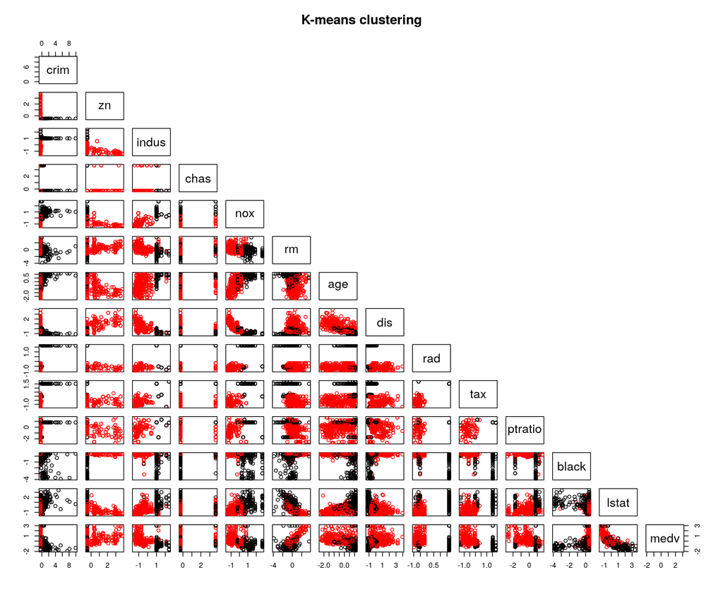

```r
km <-kmeans(boston_scaled2, centers = 2)

# plot the Boston dataset with clusters
pairs(boston_scaled2, main = "K-means clustering",col = km$cluster, upper.panel = NULL)
```

**Bonus**

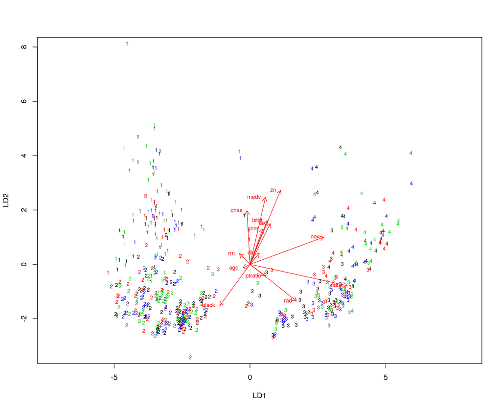

```r
boston_scaled_bonus<-as.data.frame(scale(Boston))
set.seed(12345)
km_bonus<-kmeans(dist_eu, centers = 4)

myclust<-data.frame(km_bonus$cluster)
boston_scaled_bonus$clust<-km_bonus$cluster
lda.fit_bonus<-lda(clust~., data = boston_scaled_bonus)
#lda.fit_bonus


lda.arrows <- function(x, myscale = 1, arrow_heads = 0.1, color = "red", tex = 0.75, choices = c(1,2)){
  heads <- coef(x)
  arrows(x0 = 0, y0 = 0,
         x1 = myscale * heads[,choices[1]],
         y1 = myscale * heads[,choices[2]], col=color, length = arrow_heads)
  text(myscale * heads[,choices], labels = row.names(heads),
       cex = tex, col=color, pos=2.5)
}


# plot the lda results
plot(lda.fit_bonus, dimen = 2, col=classes)
lda.arrows(lda.fit_bonus, myscale = 2.6)
```

In the above biplot, the proportion of non-retail business acres per town (indus) has the largest possible variance (that is, accounts for as much of the variability in the Boston data as possible) when I used the cluster number 4.